# Final project

Adrian Martin Bethencourt

16/08/2020

# Load the required packages

```r
library(magrittr)
library(dplyr)
library(tidyr)
library(readr)
library(ggplot2)
library(ggiraph)
library(gganimate)
library(readr)
library(viridisLite)
library(viridis)
library(reshape2)
#Install the following if required
library(hrbrthemes) #Install.packages("hrbrthemes")
library(lubridate)  #Install.packages("lubridate")
```

# 1. Import the data

```r
library(readr)
exo_data <- read_csv("exo_data.csv")
class(exo_data)
```

```
## [1] "spec_tbl_df" "tbl_df"      "tbl"         "data.frame"
```

```r
#The columns 1,16,17,18,25 are characters already.
exo_data$year %<>% as.integer
exo_data$flag %<>% as.factor
exo_data$meth %<>% as.factor
```

# 2. Exclude the exoplanets with an unknown method of discovery.

```r
exo_data<-exo_data %>% filter(meth == "transit"|
                              meth =="RV"|
                              meth =="microlensing")
```

# 3. Create a graphic which illustrates the relationship between the log-distances from the Sun and the methods of discovery.

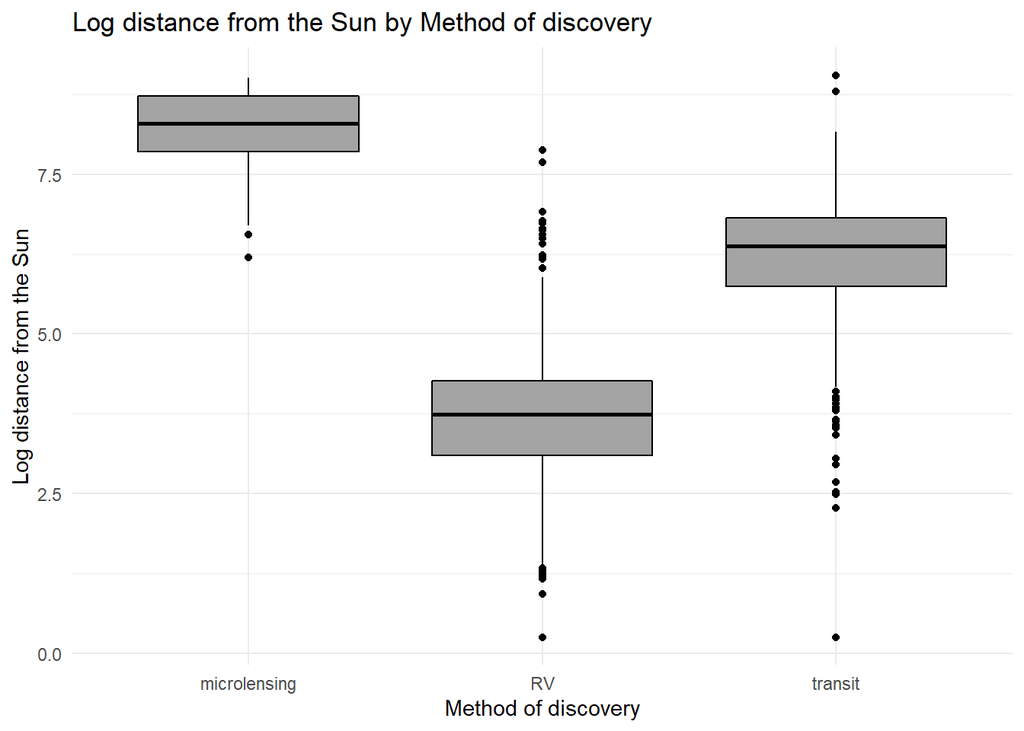

```r
p<-ggplot(exo_data, aes(x= meth, y = log(dist)))
p + geom_boxplot(fill='#A4A4A4', color="black") +
  theme_minimal()+
  scale_fill_brewer(palette="Dark2")+
  xlab("Method of discovery") +
  ylab("Log distance from the Sun") +
  ggtitle('Log distance from the Sun by Method of discovery')
```

# 4. Create scatterplots of the log-mass versus log-distances, separating by methods of discovery. Hovering with the cursor highlights the point and displays its name, and,if you click,the exoplanet’s page on the Open Exoplanet Catalogue will be opened.

(paste the id after http://www.openexoplanetcatalogue.com/planet/ ).

```r
exo_data$onclick <- sprintf("window.open(\"%s%s\")",
                            "http://www.openexoplanetcatalogue.com/planet/",
                            as.character(exo_data$id))

p<-ggplot(exo_data, aes(x = log(mass), y = log(dist), color = meth))

p2<-  p+ geom_point_interactive(aes(tooltip = id,
                                    data_id = id,
                                    onclick = onclick))+
  xlab("Log planetary mass") +
  ylab("Log distance from the Sun") +
  ggtitle('Log planetary mass by log distance from the Sun by Method')

ggiraph(code = print(p2), width = 1)
```

[interactive chart not shown]